# Australian Birds Classifier

## Create dataset

I first downloaded urls from a Google image search for various classes of Australian birds. I then uploaded these files to my notebook and then downloaded the images into folders for the various classes.

```python
from fastai.vision import *
```

```python
folder = 'galah'
file = 'urls_galah.csv'
```

```python
path = Path('data/birds')
dest = path/folder
dest.mkdir(parents=True, exist_ok=True)
```

```python
download_images(path/file, dest, max_pics=700)
```

100.00% [400/400 00:31<00:00]

```
Error https://dictionary.cambridge.org/images/thumb/galah_noun_002_15317.jpg?version=4.0.76 ('Connection aborted.', RemoteDisconnected('Remote end closed connection without response',))
```

```python
folder = 'kookaburra'
file = 'urls_kookaburra.csv'
```

```python
path = Path('data/birds')
dest = path/folder
dest.mkdir(parents=True, exist_ok=True)
```

```python
download_images(path/file, dest, max_pics=700)
```

100.00% [644/644 00:55<00:00]

```
Error https://thumbor.abcopen.net.au/7jNUuauNGqJdUuLrBJuAVyQESSY=/970x596/smart/https://uploads-abcopen.s3.amazonaws.com/assets/uploads/138427.jpg HTTPSConnectionPool(host='thumbor.abcopen.net.au', port=443): Read timed out. (read timeout=4)
Error x-raw-image:///e9249c7c049aa426d58b5e542e45fe0ffe71abc7a860e3992baaa64a8bc0f9d9 No connection adapters were found for 'x-raw-image:///e9249c7c049aa426d58b5e542e45fe0ffe71abc7a860e3992baaa64a8bc0f9d9'
```

```python
folder = 'cockatoo'
file = 'urls_cockatoo.csv'
```

```python
path = Path('data/birds')
dest = path/folder
dest.mkdir(parents=True, exist_ok=True)
```

```python
download_images(path/file, dest, max_pics=700)
```

100.00% [688/688 00:57<00:00]

[output not shown]

[output not shown]

```python
folder = 'lorikeet'
file = 'urls_lorikeet.csv'
```

```python
path = Path('data/birds')
dest = path/folder
dest.mkdir(parents=True, exist_ok=True)
```

```python
download_images(path/file, dest, max_pics=700)
```

100.00% [611/611 00:43<00:00]

[output not shown]

```python
folder = 'magpie'
file = 'urls_magpie.csv'
```

```python
path = Path('data/birds')
dest = path/folder
dest.mkdir(parents=True, exist_ok=True)
```

```python
download_images(path/file, dest, max_pics=700)
```

100.00% [674/674 00:40<00:00]

[output not shown]

```python
folder = 'gull'
file = 'urls_gull.csv'
```

```python
path = Path('data/birds')
dest = path/folder
dest.mkdir(parents=True, exist_ok=True)
```

```python
download_images(path/file, dest, max_pics=700)
```

100.00% [600/600 00:46<00:00]

[output not shown]

```python
path.ls()
```

```
[PosixPath('data/birds/galah'),
 PosixPath('data/birds/kookaburra'),
 PosixPath('data/birds/.ipynb_checkpoints'),
 PosixPath('data/birds/cockatoo'),
 PosixPath('data/birds/lorikeet'),
 PosixPath('data/birds/magpie'),
 PosixPath('data/birds/gull'),
 PosixPath('data/birds/models'),
 PosixPath('data/birds/export.pkl'),
 PosixPath('data/birds/urls_magpie.csv'),
 PosixPath('data/birds/urls_lorikeet.csv'),
 PosixPath('data/birds/urls_galah.csv'),
 PosixPath('data/birds/urls_gull.csv'),
 PosixPath('data/birds/urls_cockatoo.csv'),
 PosixPath('data/birds/urls_kookaburra.csv'),
 PosixPath('data/birds/cleaned.csv')]
```

I now check for corrupted images that cannot be opened.

```python
classes = ['galah','kookaburra','cockatoo', 'lorikeet', 'magpie', 'gull']
```

```python
for c in classes:
    print(c)
    verify_images(path/c, delete=True, max_size=700)
```

```
galah
```

100.00% [400/400 00:03<00:00]

[output not shown]

```
kookaburra
```

100.00% [642/642 00:04<00:00]

[output not shown]

100.00% [688/688 00:06<00:00]

[output not shown]

100.00% [614/614 00:05<00:00]

```
cannot identify image file <_io.BufferedReader name='data/birds/lorikeet/00000018.jpg'>
cannot identify image file <_io.BufferedReader name='data/birds/lorikeet/00000020.jpg'>
cannot identify image file <_io.BufferedReader name='data/birds/lorikeet/00000043.jpg'>
cannot identify image file <_io.BufferedReader name='data/birds/lorikeet/00000092.jpg'>
cannot identify image file <_io.BufferedReader name='data/birds/lorikeet/00000116.jpg'>
cannot identify image file <_io.BufferedReader name='data/birds/lorikeet/00000005.jpg'>
cannot identify image file <_io.BufferedReader name='data/birds/lorikeet/00000115.jpg'>
cannot identify image file <_io.BufferedReader name='data/birds/lorikeet/00000131.jpg'>
```

[output not shown]

[output not shown]

100.00% [679/679 00:04<00:00]

[output not shown]

100.00% [606/606 00:06<00:00]

[output not shown]

```python
np.random.seed(42)
data = ImageDataBunch.from_folder(path, train=".", valid_pct=0.2,
        ds_tfms=get_transforms(), size=224, num_workers=4).normalize(imagenet_stats)
```

```python
data.classes
```

```
['cockatoo', 'galah', 'gull', 'kookaburra', 'lorikeet', 'magpie']
```

Below some of the images are displayed along with their class.

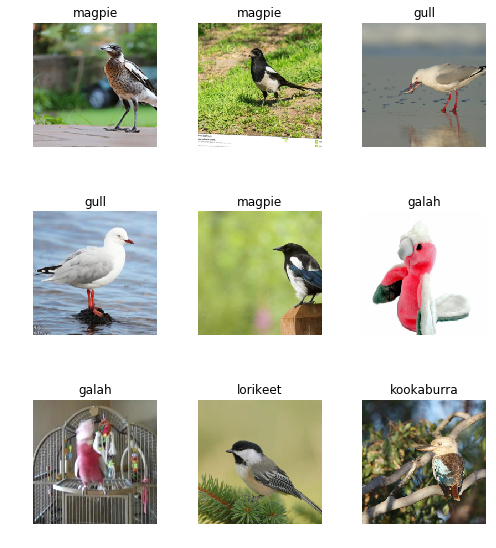

```python
data.show_batch(rows=3, figsize=(7,8))
```

```python
data.classes, data.c, len(data.train_ds), len(data.valid_ds)
```

```
(['cockatoo', 'galah', 'gull', 'kookaburra', 'lorikeet', 'magpie'],
 6,
 2797,
 699)
```

I have 6 classes with 2797 images in the training set and 699 in the validation set.

## Train a model

This model is a convolutional neural network using transfer learning using weights from the 'resnet' architecture.

```python
learn = cnn_learner(data, models.resnet34, metrics=accuracy)
```

```python
learn.model
```

[output not shown]

[output cut: 99 more lines]

```
  (1): Sequential(
    (0): AdaptiveConcatPool2d(
      (ap): AdaptiveAvgPool2d(output_size=1)
      (mp): AdaptiveMaxPool2d(output_size=1)
    )
    (1): Flatten()
    (2): BatchNorm1d(1024, eps=1e-05, momentum=0.1, affine=True, track_running_stats=True)
    (3): Dropout(p=0.25)
    (4): Linear(in_features=1024, out_features=512, bias=True)
    (5): ReLU(inplace)
    (6): BatchNorm1d(512, eps=1e-05, momentum=0.1, affine=True, track_running_stats=True)
    (7): Dropout(p=0.5)
    (8): Linear(in_features=512, out_features=6, bias=True)
  )
)
```

```python
learn.fit_one_cycle(4)
```

Total time: 01:29

| epoch | train_loss | valid_loss | accuracy | time |
| --- | --- | --- | --- | --- |
| 0 | 0.791787 | 0.191363 | 0.939914 | 00:22 |
| 1 | 0.394012 | 0.164904 | 0.947067 | 00:22 |
| 2 | 0.253916 | 0.156304 | 0.957082 | 00:22 |
| 3 | 0.187854 | 0.153321 | 0.955651 | 00:22 |

95.5% accurate

```python
learn.save('stage-1')
```

I now unfreeze the resnet layers to allow those weights to be modified to see if that improves accuracy.

```python
learn.unfreeze()
```

```python
learn.lr_find()
```

```
LR Finder is complete, type {learner_name}.recorder.plot() to see the graph.
```

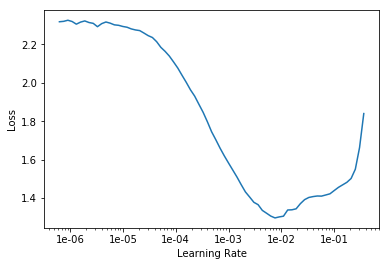

```python
learn.recorder.plot()
```

```python
learn.fit_one_cycle(2, max_lr=slice(3e-5,3e-3)) # adjust the learning rate
```

Total time: 00:46

| epoch | train_loss | valid_loss | accuracy | time |
| --- | --- | --- | --- | --- |
| 0 | 0.519234 | 0.169848 | 0.952790 | 00:22 |
| 1 | 0.258650 | 0.126777 | 0.961373 | 00:23 |

This has improved to 96.1% accurate

```python
learn.save('stage-2')
```

```python
learn.load('stage-2');
```

Have a look at poor predictions

```python
interp = ClassificationInterpretation.from_learner(learn)
losses, idxs = interp.top_losses()
len(data.valid_ds)==len(losses)==len(idxs)
```

```
True
```

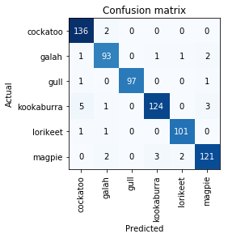

```python
interp.plot_confusion_matrix()
```

This graph shows where the model made mistakes - for example, if you look in the first column, fourth row, there were 5 kookaburras that were misclassified as cockatoos.

```python
interp.most_confused(min_val=2)
```

```
[('kookaburra', 'cockatoo', 5),
 ('kookaburra', 'magpie', 3),
 ('magpie', 'kookaburra', 3),
 ('cockatoo', 'galah', 2),
 ('galah', 'magpie', 2),
 ('magpie', 'galah', 2),
 ('magpie', 'lorikeet', 2)]
```

[figure not shown]

```python
interp.plot_top_losses(9, figsize=(15,11), heatmap=False)
```

We can see that there are some images that should not be in this dataset, cleaning the data may improve model performance.

## Clean the data

```python
from fastai.widgets import *
```

```python
db = (ImageList.from_folder(path)
                   .split_none()
                   .label_from_folder()
                   .transform(get_transforms(), size=224)
                   .databunch()
     )
```

```python
learn_cln = cnn_learner(db, models.resnet34, metrics=error_rate)
learn_cln.load('stage-2'); # this loads the weights to to model
```

```python
ds, idxs = DatasetFormatter().from_toplosses(learn_cln)
```

```python
ImageCleaner(ds, idxs, path)
```

Find duplicates

```python
db = (ImageList.from_csv(path, 'cleaned.csv', folder='.')
                    .split_none()
                    .label_from_df()
                    .transform(get_transforms(), size=224)
                    .databunch()
      )
```

```python
learn_cln = cnn_learner(db, models.resnet34, metrics=error_rate)
learn_cln.load('stage-2');
```

```python
ds, idxs = DatasetFormatter().from_similars(learn_cln)
```

```
Getting activations...
```

100.00% [54/54 00:14<00:00]

```
Computing similarities...
```

```python
ImageCleaner(ds, idxs, path, duplicates=True)
```

```python
data = ImageDataBunch.from_csv(path, csv_labels='cleaned.csv', valid_pct=0.2,
        ds_tfms=get_transforms(), size=224, num_workers=4).normalize(imagenet_stats)
```

## Train a new model on the cleaned dataset

```python
learn_cln = cnn_learner(data, models.resnet34, metrics=accuracy)
```

```python
learn_cln.fit_one_cycle(4)
```

Total time: 01:23

| epoch | train_loss | valid_loss | accuracy | time |
| --- | --- | --- | --- | --- |
| 0 | 0.749172 | 0.175490 | 0.950220 | 00:21 |
| 1 | 0.364388 | 0.155911 | 0.957540 | 00:21 |
| 2 | 0.230142 | 0.157330 | 0.960469 | 00:20 |
| 3 | 0.165762 | 0.154792 | 0.961933 | 00:20 |

```python
learn_cln.save('stage-1_cln')
```

```python
learn_cln.unfreeze()
```

```python
learn_cln.fit_one_cycle(2, max_lr=slice(1e-6,1e-4))
```

Total time: 00:42

| epoch | train_loss | valid_loss | accuracy | time |
| --- | --- | --- | --- | --- |
| 0 | 0.115978 | 0.147389 | 0.959004 | 00:21 |
| 1 | 0.106179 | 0.145030 | 0.960469 | 00:21 |

Accuracy has not improved.

```python
learn_cln.save('stage-2-cln')
```

## Make a prediction

```python
learn_cln.load('stage-2-cln');
```

```python
learn_cln.export()
```

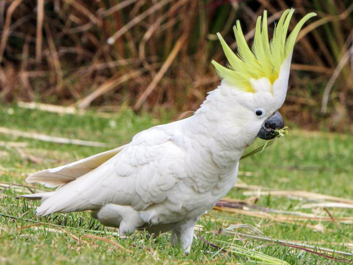

```python
img = open_image(path/'cockatoo'/'00000001.jpg')
img
```

```python
learn = load_learner(path)
```

```python
pred_class,pred_idx,outputs = learn.predict(img)
pred_class
```

```
Category cockatoo
```